# Lab 7.1 - Visualizing spatial information

# 1 Accessing spatial data

In addition to the functions for statistical calculation that we have already seen, in R we can find several packages that allow to interact with spatial data, both in vector and raster format. Some of the main GIS packages in R are:

- `rgdal`
- `Maptools`
- `raster`
- `GISTools`
- `Sp`
- `sf`

Basically, these are libraries (packages) allow as reading and managing spatial data objects, such as ESRI shapefiles or raster files in ASCII format or any other GDAL supported format. These packages also allow you to create thematic maps from spatial data or to perform most of the geoprocesses of a Geographic Information System (GIS).

## 1.1 Working with vector layers

The `sf` package will allow us, among other things, to access information contained in spatial vector layers (points, lines and polygons). This package incorporates many other functions for spatial data manipulation, but they are way beyond the scope of this course.

Vector information is characterized by representing elements by points, lines and polygons. Each of these elements is related to a record within an attribute table associated with spatial information. If you are not familiar with GIS or spatial data take a quick look to http://gisgeography.com/spatial-data-types-vector-raster/.

By reading vectors into R we can access both the spatial information (location) and thematic (attribute table). But the coolest thing about `sf` it’s not that translate vector layers into `data.frames`. The best thing above all is that **it is fully compatible with `dplyr`**. Contrary to other packages like `rgdal`, `sf` implements a class object that allows using pipes and most functions in `dplyr` using variables from the vector attribute table.

To read a vector `shape` layer into R we proceed as follows:

```r
grid <- read_sf("data/Fires_grid_CCAA.shp")
```

The previous chunk of code loads the layer *Fires_grid_CCAA* into an R object we called `grid`. This layer contains a grid polygon division that matches the `CODCUAD` identifier in the `fires` data frame.

> Note that shapefiles are composed by many individual files, sharing the name but with differnt file extensions

Next, we will see how to use `ggplot` for mapping. It is actually similar to what we have done so far. The only specific thing is the use of `geom_sf’ to display spatial vector layers. You will notice how once we are within that particular geom we can use regular aesthetics to display info.

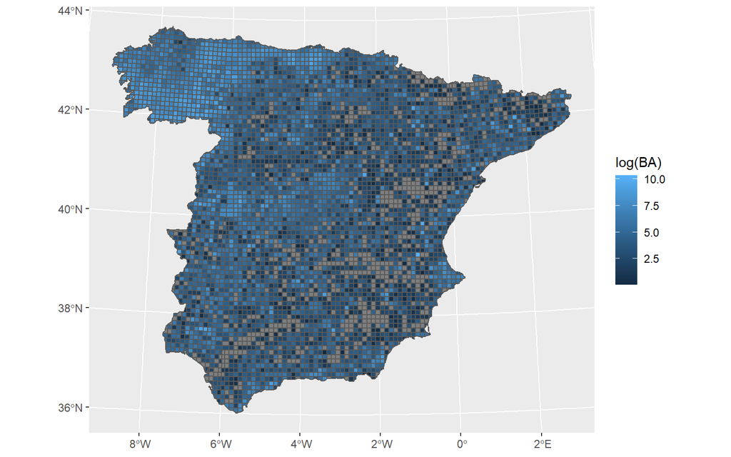

```r
# First we summarise number of fires and burned area by CODCUAD
fire.features.grid <- fires %>%
    filter(YEAR > 1994, BAREA > 1) %>%
    group_by(CODCUAD, .drop = F) %>%
    summarise(N = n(), BA = sum(BAREA))

# Then we join the fire dataset to the grid
grid %>%
    left_join(fire.features.grid, by = c(Cod_Cuad = "CODCUAD")) %>%
    ggplot() + geom_sf(aes(fill = log(BA)))
```

Notice how the results slightly differs from what we saw in regular plots. The axis labels are now geographic coordinates rather than unit coordinates. Other than that, the plot behaves the same.

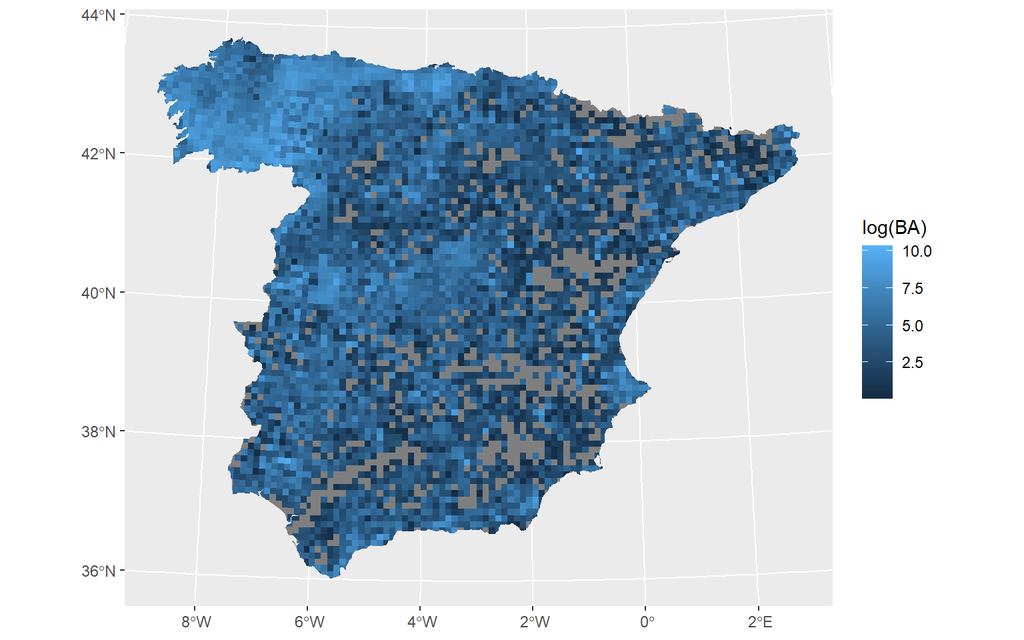

```r
# First we summarise number of fires and burned area by CODCUAD
fire.features.grid <- fires %>%
    filter(YEAR > 1994, BAREA > 1) %>%
    group_by(CODCUAD, .drop = F) %>%
    summarise(N = n(), BA = sum(BAREA))

# Then we join the fire dataset to the grid
grid %>%
    left_join(fire.features.grid, by = c(Cod_Cuad = "CODCUAD")) %>%
    ggplot() + geom_sf(aes(fill = log(BA)), color = NA)
```

## 1.2 Working with raster layers

The only thing we would have to do is to introduce the information related to the independent variables. For this we will use some of the functionalities available in the raster package. In this way we will also automate the obtaining of the independent variables.

The `raster` package provides utilities for manipulating geographic information in raster format. This package, along with maptools, converts R into a pseudo-GIS environment, allowing you to use most basic raster analysis functions. The raster package allows:

- Create raster objects.
- Manipulation of very heavy files.
- Map algebra and overlay functions.
- Distances and connection analysis.
- Conversion of polygons, lines and points to raster.
- Calculate **spatial predictions** of regression models.
- Mapping from raster maps.
- Reading and writing various types of raster files.

Of all these functionalities available we will focus on:

- Creating raster objects.
- Calculate predictions of regression models.
- Elaboration of maps.
- Reading and writing various types of raster files.

The remainnig functions can be found in a more intuitive way in any desktop GIS software. However, in some cases it may be more operative to use them directly in R.

### 1.2.1 Loading raster layers

Again, the most first thing to do is reading a raster layer. Once `raster` package is installed and loade we can call the `raster()` function and load any raster layer. Let’s see an example using the layer *dem_rioja.tif* that you can find in the folder *Raster*. It is a Digital Elevation Model (DEM)[^1] of the Autonomous Community of La Rioja[^2].

The first thing is to install the package. Unlike in other occasions this time we will specify the argument `dep = TRUE`. The raster package has many dependencies, ie, needs functions from other packages in order to work properly. It could be very annoying installing them one by one so we use that extra argument to ensure everything will work fine:

```r
# install.packages('raster', dep = TRUE)
library(raster)
```

Once installed and activated we can call the `raster()` function to read raster layer.

```r
dem <- raster("data/dem_rioja.tif")
```

Once we loaded the raster layer we are ready to display it using ggplot. There are two ways of doing so. The *canonic* way involves converting the raster layer into a regular data frame and then use `geom_raster` or `geom_tile`. A raster layer is essentially a matrix where each pixel can be individualized using coordinates and the value that the pixel holds. That produces a dataframe with x, y variables and a third z variable with the variable contained in the raster:

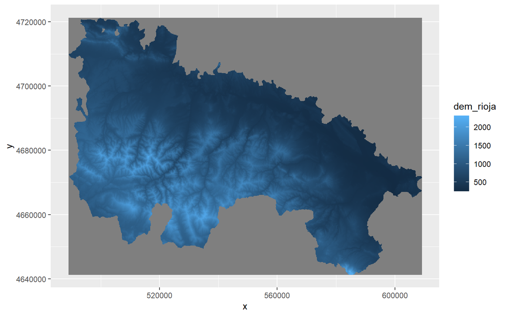

```r
raster::as.data.frame(dem, xy = TRUE) %>%
    ggplot() + geom_raster(aes(x = x, y = y, fill = dem_rioja))
```

The second option is using the function `gplot` from package `rasterVis`. This allows using raster objects as data in the plot call. Other than that, the `gplot` function works the same `ggplot` does.

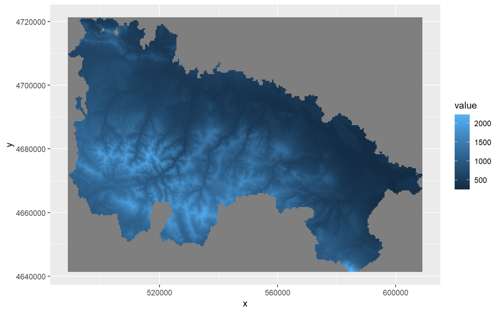

```r
library(rasterVis)
gplot(dem) + geom_tile(aes(fill = value))
```